# BMD: SDM example

Julian Oeser

2025-05-20

# SDM Example

This is an R-script demonstrating a SDM modeling workflow. A similar workflow may be implemented in SDM-based VREs. The purpose of the script is to demonstrate (in a simplified way) what a workflow could look like, and I did not check the model for ecological realism (which typically should be done!).

This is an annotated version aimed at explaining intermediate processing steps and data requirements. A version implementing a Shiny-based GUI (e.g., selecting the species of interest with a drop-down menu, etc.) can be implemented soon as an additional demo.

For demonstration purposes, I chose to work at a fairly low spatial resolution (~10km raster cell size). When working at higher spatial resolutions (e.g., 1km) computational costs can be much larger. On the other hand, I did no optimize the code for speed, and some performance gains can be made (e.g., via parallelization).

All visualizations are quick-and-dirty and could be optimized for display within VREs.

## Preparation

### Working directory

First, let’s set the working directory of R to the location of the source file (i.e., this script). NOTE: this only works in Rstudio. Running the code contained in this script in R requires you to have downloaded the folder containing the .csv file containing the example occurrence dataset, the R file containing required functions, and the folder of .tif files containing raster datasets used in the analysis.

```r
setwd(dirname(rstudioapi::getActiveDocumentContext()$path))
```

### Packages and functions

Second, let’s install and load all packages required for this example (if missing). A note on packages / dependencies: In the development of VREs, we should probably aim to keep dependencies to other packages minimal. Yet, some dependencies to well-maintained packages will exist (e.g., sf and terra for spatial data processing).

Also, we are sourcing (loading) the script containing the functions I wrote and/or adapted for data processing and modeling. In the future, I can make these functions available as an R-package via a repository (e.g., Git / GitHub).

```r
packages <- c("tidyverse", "sf", "terra","fastshap", "mapview", "randomForest", "blockCV", "parallel")

for (pkg in packages) {
  if (!require(pkg, character.only = TRUE)) {
    install.packages(pkg)
    library(pkg, character.only = TRUE)
  }
}

source("bmd_functions.R")
```

### Load data

Next, let’s load our example dataset. I downloaded presence occurrence records for all bat (Chiroptera) species listed in the annex II of the habitats directive (13 species; see here for all annex II species: https://eunis.eea.europa.eu/references/2325/species). I downloaded the dataset via the rgbif package (https://docs.ropensci.org/rgbif/articles/rgbif.html). The lines of commented-out code show the function call with which I downloaded the data. To run this, you need to install and setup the rgbif package.

Note: The package also allows you to download occurrence data cubes (developed by the B-Cubed project). I tested this feature and noticed two things:

1. The SQL-based downloads are slower than using the `occ_download` function (see here: https://docs.ropensci.org/rgbif/articles/gbif_sql_downloads.html)
2. Although the occurrence cubes have the option to download bias information, this only seems to add the number of target-group taxa counts at the locations of the occurrence data. However, for target-group bias-adjustment in SDMs (see e.g., https://doi.org/10.1111/ddi.13442), we need the full set of locations of all target-group taxa.

In addition to the occurrence data (“bats_europe.csv”), we are also loading several raster datasets:

1. A raster defining land areas (derived from CHELSA: https://chelsa-climate.org/)
2. A raster defining the extent of our area-of-interest (Europe), for which we want to make model predictions.
3. 19 bioclimatic variables from CHELSA (candidate predictors) for current climate conditions (see here for an overview of what the variables indicate: https://www.worldclim.org/data/bioclim.html)
4. The same 19 bioclimatic variables for based on a single climate model and future period (2071-2100)

Note: Even though we want to make predictions for Europe, we need to train our models across the full distribution of the species to avoid niche truncation (i.e., excluding parts of the environmental niche of a species during model training). When projecting models for future climate scenarios, we would typically first create an ensemble of all available climate models (N=5 for CHELSA), but I kept it simple here.

As an example species, I chose *Rhinolophus ferrumequinum* (https://en.wikipedia.org/wiki/Greater_horseshoe_bat)

```r
### code to download bat occurrences via the rgbif package
# GBIF taxon ids of all bats listed in annex II of the habitats directive
# taxon_ids <- c(2432614, 2432655, 2432621, 2432666, 2432416, 2432470, 2432452, 2432430, 2432414, 2432427, 2432509, 2432582, 2432953)
#
# dl <- rgbif::occ_download(
#   pred_in("taxonKey", taxon_ids),
#   pred("occurrenceStatus","PRESENT"),
#   pred_gte("year", 1980),
#   pred("hasCoordinate", TRUE),
#   pred("hasGeospatialIssue", FALSE),
#   format = "SIMPLE_CSV",
#   pred_or(
#     pred_lt("coordinateUncertaintyInMeters",1000),
#     pred_isnull("coordinateUncertaintyInMeters")
#   ),
#   pred_in("basisOfRecord",c("HUMAN_OBSERVATION", "PRESERVED_SPECIMEN"))
# )
#
# occ_download_wait(dl)
# dat <- occ_download_get(dl) |> occ_download_import()

# load bat occurrence data and select required columns
presence_full <- read_delim("bats_europe.csv", delim = "\t") %>%
  select(species, decimalLongitude, decimalLatitude)
```

```r
landmask <- rast("raster_data/landseamask_agg10.tif")
landmask_europe <- rast("raster_data/landseamask_europe_agg10.tif")

# convert to spatial sf object
presence_full_sf <- st_as_sf(presence_full, coords = c("decimalLongitude", "decimalLatitude"), crs = 4326)

# which species are present in the dataset?
all_species <- unique(presence_full$species)

# plot a small fraction of the data as a check
presence_full_sf_plot <- sample_frac(presence_full_sf, 0.05)
mapview(presence_full_sf_plot)
```

[interactive chart not shown]

```r
# select an example species for demonstration
example_species <- "Rhinolophus ferrumequinum"

message(paste0("The chosen example species is: " ), example_species)
```

```
## The chosen example species is: Rhinolophus ferrumequinum
```

```r
# keep only one occurence point per raster grid cell in the presence and background datasets
presence_sf <- presence_full_sf %>%
  filter(species == example_species) %>%
  remove_duplicates_per_cell(landmask)

presence_tg_sf <- presence_full_sf %>%
  filter(species != example_species) %>%
  remove_duplicates_per_cell(landmask)

# load raster datasets containing the 19 bioclimatic variables from CHELSA
climate_current <- rast(list.files("raster_data/1981_2010/", "_agg10.tif", full.names = TRUE))
names(climate_current) <- str_extract(names(climate_current), "bio[0-9]{1,2}")
climate_future <- rast(list.files("raster_data/2071_2100//", "_agg10.tif", full.names = TRUE))
names(climate_future) <- str_extract(names(climate_future), "bio[0-9]{1,2}")
```

## 1. Sample background

In the first processing step, we are creating sample of background/pseudo-absence points required for building SDMs. Here, we are using one of the most simple approaches to account for sampling bias in the occurrence dataset, namely selecting background points among locations where target-group taxa have been observed (i.e., taxa with similar sampling bias, in our case all other bat species of interest). Other approaches could be used, e.g., creating a kernel density grid from target-group observations or selecting background points based on buffers of the presence records (background thickening: https://doi.org/10.1111/ecog.04503), which would not require information on target-group occurrence.

```r
# test whether we can sample five times as many backgrounds as presences, otherwise use maximum available
n_samples <- ifelse(nrow(presence_sf)*5 > nrow(presence_tg_sf), nrow(presence_tg_sf), nrow(presence_sf)*5)

background_points <- presence_tg_sf %>%
  sample_n(n_samples) %>%
  dplyr::select(-species)

# plot small fraction of the data as a check
background_points_plot <- sample_frac(st_as_sf(background_points), 0.05)
mapview(background_points_plot)
```

[interactive chart not shown]

```r
# combine presence and background points
pb <- bind_rows(
  presence_sf %>% dplyr::select() %>% mutate(occ = 1),
  st_sf(background_points) %>% mutate(occ = 0)
)
```

## 2. Extract candidate predictor variables

Next, we are extracting the values of the current climate variables at all presence and background locations to generate a data frame used for model building.

NOTE: When using dynamic predictor variables that vary at temporal resolutions comparable to the occurrence data (e.g., land-cover time series), we would need to implement a temporal matching of the data, i.e., extract values for the specific time period in which an observation was observed.

```r
# extract values of candidate predictors (19 bioclimat variables)
pb_ext <- terra::extract(climate_current, vect(pb), ID =FALSE)

# combine data into model data frame
model_df <- pb %>%
  bind_cols(pb_ext) %>%
  mutate(occ = as.factor(occ)) %>%
  bind_cols(st_coordinates(.) %>% setNames(c("X", "Y"))) %>%
  st_set_geometry(NULL) %>%
  filter(complete.cases(.))

# convert to spatial sf object
model_sf <- st_as_sf(model_df, coords = c("X", "Y"), crs = 4326)
```

## 3. Select predictor variables

To reduce data size and aid model interpretability and transferability, we are selecting a subset of predictor variables to be used in the SDM for the example species. Here, we use a simple automated approach that selects uncorrelated variables (r < 0.7) and retains those with the best univariate performance based on AIC values of a logistic regression. Other automated approaches could be implemented (e.g., based on regularization or boosting approaches: https://doi.org/10.1016/j.ecoinf.2023.102080) or, for certain VREs, predictors could be pre-defined to ensure ecologically meaningful variables are used in the models.

```r
selected_variables <- select_uncorrelated_features(model_df, variable_names = setdiff(names(climate_current), "bio14"), univariate_metric = "aic", cor_cut = 0.7)
model_sf_select <- model_sf %>% dplyr::select(all_of(c("occ", selected_variables)))
```

## 4. Tune hyperparameters

Many SDM algorithms require an optimization of hyperparameters (model tuning) to avoid overfitting (i.e., build overly complex models that do not transfer well across space and time). In this example, I will use random forests as an example algorithm (specifically, down-sampled random forests as discussed here: https://nsojournals.onlinelibrary.wiley.com/doi/10.1111/ecog.05615#citedby-section). The algorithm has several potential tuning parameters, but we are focusing on the minimum node size as an example (see: https://www.rdocumentation.org/packages/randomForest/versions/4.7-1.2/topics/randomForest).

Tuning hyperparameters typically requires testing a set of hyperparameter values and assessing their impact on predictive via a cross-validation. As a cross-validation strategy, we are here using spatial blocking implemented via the blockCV package (https://github.com/rvalavi/blockCV). Spatial or environmental blocking are typically the most useful approaches in SDMs, since random cross-validation is over-optimistic and prone to select models that overfit the data (see: https://doi.org/10.1111/ecog.02881)

For large data sizes and/or complex algorithms, this processing step can involve fairly large computational costs. There is the potential for more efficient tuning by more complex tuning approaches than grid search (e.g., bayesian optimization).

```r
# create spatial folds based on hexagons via the blockCV-package
model_df_folds <- folds_spatial(model_sf_select, k = 5)
```

[figure not shown]

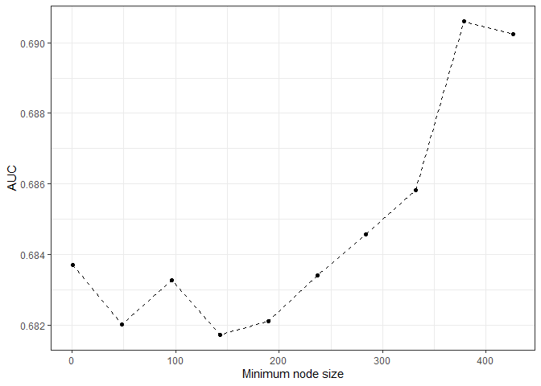

```r
# create a regular grid for tuning the nodesize parameter
tune_grid <- tibble(nodesize = round(seq(1, nrow(model_df_folds)*0.05, length.out = 10)))

# run grid search / cross valiodation
tunings_results_rf <- tune_model(fit_rf,
                                 predictors = selected_variables,
                                 pred_fun = pred_rf,
                                 model_df = model_df_folds,
                                 tune_grid = tune_grid)


# select the model with the highest area under the ROC curve (AUC) value (other performance metrics could be used in addtion or instead)
selected_run <- which.max(tunings_results_rf$auc)

# plot performance across minimum node size values
ggplot(tunings_results_rf, aes(nodesize, auc)) +
  geom_point() +
  geom_line(linetype = 2) +
  theme_bw() +
  xlab("Minimum node size") +
  ylab("AUC")
```

## 5. Fit full model

This step fits the final models with the selected hyperparameter(s) based on all available data for the example species.

```r
nodesize <- tune_grid$nodesize[selected_run]
m_rf <- fit_rf(model_sf_select, selected_variables, ntree = 500, nodesize = nodesize)
```

## 6. Predict model

Next, we generate predictions across our area of interest (Europe). In addition, to identify areas in which our model needs extrapolate (i.e., predict to areas with values outside the training ranges or new combinations of variable values), we calculate ExDet scores (see: https://doi.org/10.1111/ddi.12209). These can help highlight areas in which our model predictions are more uncertain.

Note: The prediction of models will typically often be one of the computationally most expensive tasks in the modeling workflow, particularly when we use finer spatial resolutions.

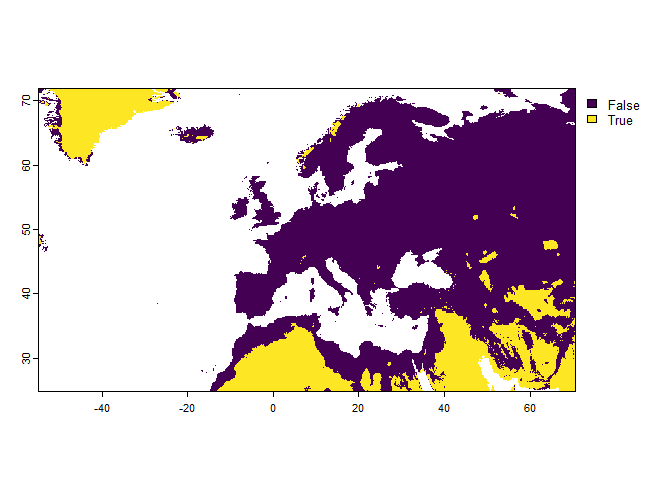

```r
# crop and mask the selected predictor variables to the area of interest for which we want to make model predictions
predictors_europe_current <- crop(mask(subset(climate_current, selected_variables), landmask), landmask_europe)
predictors_europe_future <- crop(mask(subset(climate_future, selected_variables), landmask), landmask_europe)

# create extrapolation surfaces to identify areas in which the model predictions are less certain
ref_df <- model_df %>% dplyr::select(all_of(selected_variables))
extrapolation <- extrapolation_exdet(predictors_europe_future, ref_df)

# plot areas in with type-I novelty (variables outside the training range). See the paper linked above for details on the interpretation of outputs.
plot(extrapolation[["nt1"]] < 0)
```

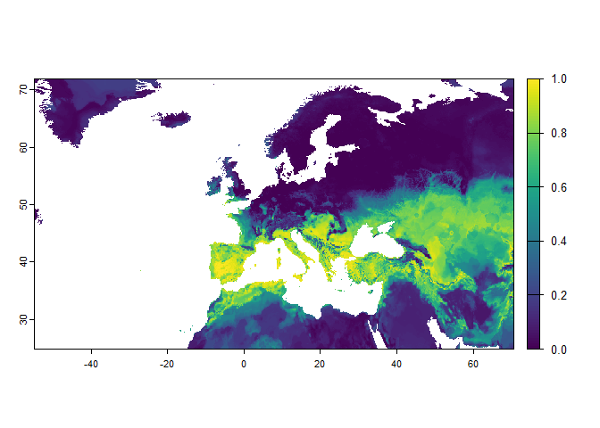

```r
# predict models across the area of interest
pred_current_rf <- terra::predict(predictors_europe_current,
                                  model = m_rf, fun = pred_rf)

pred_future_rf <- terra::predict(predictors_europe_future,
                                  model = m_rf, fun = pred_rf)


# plot predictions and their differences
plot(pred_current_rf)
```

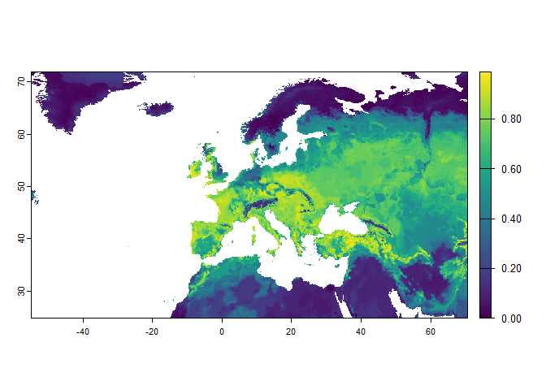

```r
plot(pred_future_rf)
```

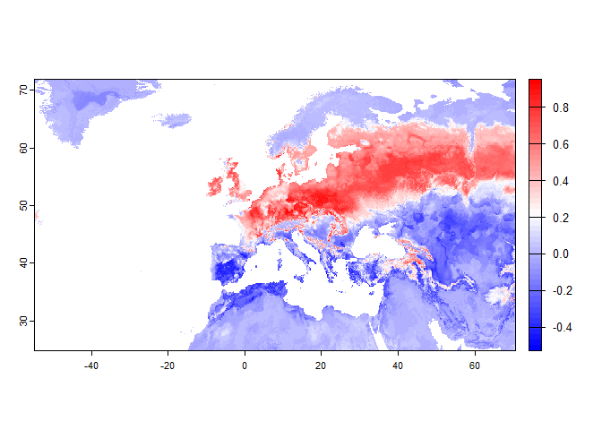

```r
plot(pred_future_rf-pred_current_rf, col = map.pal("differences"))
```

## 7. Attribute changes

As a final step, we may want to attribute predicted changes to the predictor variables in the model. For this, I am applying SHAP / Shapley values (see: https://christophm.github.io/interpretable-ml-book/shapley.html). This is a model-agnostic approach (i.e., can be applied to any algorithm) for identifying the contribution of predictors in a predictive model.

Unfortunately, calculating SHAP values is computationally expensive. For demonstration purposes, we therefore down-scale the predictor variables by a factor of 10 before running attribution. The computations are run using the fastshap package (https://bgreenwell.github.io/fastshap/). Note that the script uses parallel processing across 10 cores here, you can reduce the number of cores or set them to 1 to run everything sequentially.

The output can be interpreted as the marginal contribution of each predictor variable when changing the prediction dataset from the current to the future climate (i.e., how does each variable in the model contribute to changes in environmental suitability for the target species?).

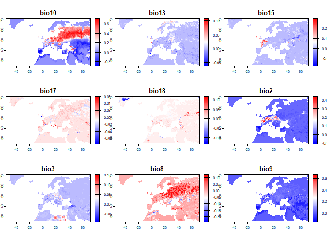

```r
attribution_results_raster <- attribution_raster(m_rf,
                                                 aggregate(predictors_europe_current, 10),
                                                 aggregate(predictors_europe_future, 10),
                                                 pred_fun = pred_rf, nsim = 1, ncores = 10)
plot(attribution_results_raster, col = map.pal("differences"))
```